# Practice Solutions

Getting Started in R and Rstudio

Author

Affiliation

Jessica Minnier, Meike Niederhausen

OHSU OCTRI-BERD

Published

September 19, 2024

## 0.1 Load the packages

```r
library(tidyverse)
library(writexl)
library(rstatix)
library(janitor)
library(naniar)
library(gt)
library(gtsummary)
library(readxl)  # part of tidyverse, but not the tidyverse core
```

# 1 Practice time! (part 1)

Use R code to answer the following questions.

1. Open the Excel file `yrbss_demo.xlsx` in the *data* *folder* to familiarize yourself with it.
2. Load the dataset `yrbss_demo.xlsx`. Make sure the name of the loaded data is `yrbss_data`.

```r
# library(readxl)
# note we are saving the data from the Excel file in our environment
# with the object name yrbss_data
yrbss_data <- read_excel("data/yrbss_demo.xlsx")
```

3. What are the column names?

```r
names(yrbss_data)
```

```
[1] "record"   "age"      "sex"      "grade"    "race4"    "race7"    "bmi"
[8] "stweight"
```

```r
# can also use glimpse:
glimpse(yrbss_data)
```

```
Rows: 20,000
Columns: 8
$ record   <dbl> 931897, 333862, 36253, 1095530, 1303997, 261619, 926649, 1309…
$ age      <chr> "15 years old", "17 years old", "18 years old or older", "15 …
$ sex      <chr> "Female", "Female", "Male", "Male", "Male", "Male", "Male", "…
$ grade    <chr> "10th", "12th", "11th", "10th", "9th", "9th", "11th", "12th",…
$ race4    <chr> "White", "White", "Hispanic/Latino", "Black or African Americ…
$ race7    <chr> "White", "White", "Hispanic/Latino", "Black or African Americ…
$ bmi      <dbl> 17.1790, 20.2487, NA, 27.9935, 24.4922, NA, 20.5435, 19.2555,…
$ stweight <dbl> 54.43, 57.15, NA, 85.73, 66.68, NA, 70.31, 58.97, 123.38, NA,…
```

4. How many rows and columns are in `yrbss_data`?

```r
nrow(yrbss_data)
```

```
[1] 20000
```

```r
ncol(yrbss_data)
```

```
[1] 8
```

```r
# both rows & columns:
dim(yrbss_data)
```

```
[1] 20000     8
```

5. Which variables are numeric (quantitative)?

```r
glimpse(yrbss_data)
```

```
Rows: 20,000
Columns: 8
$ record   <dbl> 931897, 333862, 36253, 1095530, 1303997, 261619, 926649, 1309…
$ age      <chr> "15 years old", "17 years old", "18 years old or older", "15 …
$ sex      <chr> "Female", "Female", "Male", "Male", "Male", "Male", "Male", "…
$ grade    <chr> "10th", "12th", "11th", "10th", "9th", "9th", "11th", "12th",…
$ race4    <chr> "White", "White", "Hispanic/Latino", "Black or African Americ…
$ race7    <chr> "White", "White", "Hispanic/Latino", "Black or African Americ…
$ bmi      <dbl> 17.1790, 20.2487, NA, 27.9935, 24.4922, NA, 20.5435, 19.2555,…
$ stweight <dbl> 54.43, 57.15, NA, 85.73, 66.68, NA, 70.31, 58.97, 123.38, NA,…
```

- Record, bmi, and stweight are numeric, although record actually serves as a categorical variable.
- Interestingly age and grade are not.
6. Which variables are character?

```r
glimpse(yrbss_data)
```

```
Rows: 20,000
Columns: 8
$ record   <dbl> 931897, 333862, 36253, 1095530, 1303997, 261619, 926649, 1309…
$ age      <chr> "15 years old", "17 years old", "18 years old or older", "15 …
$ sex      <chr> "Female", "Female", "Male", "Male", "Male", "Male", "Male", "…
$ grade    <chr> "10th", "12th", "11th", "10th", "9th", "9th", "11th", "12th",…
$ race4    <chr> "White", "White", "Hispanic/Latino", "Black or African Americ…
$ race7    <chr> "White", "White", "Hispanic/Latino", "Black or African Americ…
$ bmi      <dbl> 17.1790, 20.2487, NA, 27.9935, 24.4922, NA, 20.5435, 19.2555,…
$ stweight <dbl> 54.43, 57.15, NA, 85.73, 66.68, NA, 70.31, 58.97, 123.38, NA,…
```

- Age, sex, grade, race4, and race7 are character variables.

# 2 Practice time! (part 2)

1. Create a contingency table for `race4` and `race7`, with both percentages and counts. What is the difference between these two variables?

```r
yrbss_data %>%
  tabyl(race7, race4) %>%
  adorn_percentages() %>%
  adorn_pct_formatting() %>%
  adorn_ns() %>%
  adorn_title(placement = "combined") %>%
  gt()
```

| race7/race4 | All other races | Black or African American | Hispanic/Latino | White | NA_ |
| --- | --- | --- | --- | --- | --- |
| Am Indian / Alaska Native | 100.0% (711) | 0.0% (0) | 0.0% (0) | 0.0% (0) | 0.0% (0) |
| Asian | 100.0% (1,597) | 0.0% (0) | 0.0% (0) | 0.0% (0) | 0.0% (0) |
| Black or African American | 0.0% (0) | 100.0% (4,093) | 0.0% (0) | 0.0% (0) | 0.0% (0) |
| Hispanic/Latino | 0.0% (0) | 0.0% (0) | 100.0% (4,670) | 0.0% (0) | 0.0% (0) |
| Multiple - Non-Hispanic | 100.0% (1,455) | 0.0% (0) | 0.0% (0) | 0.0% (0) | 0.0% (0) |
| Native Hawaiian/other PI | 100.0% (473) | 0.0% (0) | 0.0% (0) | 0.0% (0) | 0.0% (0) |
| White | 0.0% (0) | 0.0% (0) | 0.0% (0) | 100.0% (5,814) | 0.0% (0) |
| NA | 40.2% (477) | 0.0% (0) | 0.0% (0) | 0.0% (0) | 59.8% (710) |

2. Create a contingency table for `race4` and `race7`, with both percentages and counts, stratified by `grade`.

```r
yrbss_data %>%
  tabyl(race7, race4, grade) %>%
  adorn_percentages() %>%
  adorn_pct_formatting() %>%
  adorn_ns() %>%
  adorn_title(placement = "combined") # gt doesn't work here
```

```
$`10th`
               race7/race4 All other races Black or African American
 Am Indian / Alaska Native    100.0% (187)              0.0%     (0)
                     Asian    100.0% (403)              0.0%     (0)
 Black or African American      0.0%   (0)            100.0% (1,048)
           Hispanic/Latino      0.0%   (0)              0.0%     (0)
   Multiple - Non-Hispanic    100.0% (372)              0.0%     (0)
  Native Hawaiian/other PI    100.0%  (89)              0.0%     (0)
                     White      0.0%   (0)              0.0%     (0)
                      <NA>     44.8% (107)              0.0%     (0)
 Hispanic/Latino          White         NA_
    0.0%     (0)   0.0%     (0)  0.0%   (0)
    0.0%     (0)   0.0%     (0)  0.0%   (0)
    0.0%     (0)   0.0%     (0)  0.0%   (0)
  100.0% (1,124)   0.0%     (0)  0.0%   (0)
    0.0%     (0)   0.0%     (0)  0.0%   (0)
    0.0%     (0)   0.0%     (0)  0.0%   (0)
    0.0%     (0) 100.0% (1,445)  0.0%   (0)
    0.0%     (0)   0.0%     (0) 55.2% (132)

$`11th`
               race7/race4 All other races Black or African American
 Am Indian / Alaska Native    100.0% (149)                0.0%   (0)
                     Asian    100.0% (411)                0.0%   (0)
 Black or African American      0.0%   (0)              100.0% (997)
           Hispanic/Latino      0.0%   (0)                0.0%   (0)
   Multiple - Non-Hispanic    100.0% (336)                0.0%   (0)
  Native Hawaiian/other PI    100.0% (129)                0.0%   (0)
                     White      0.0%   (0)                0.0%   (0)
                      <NA>     47.5% (125)                0.0%   (0)
 Hispanic/Latino          White         NA_
    0.0%     (0)   0.0%     (0)  0.0%   (0)
    0.0%     (0)   0.0%     (0)  0.0%   (0)
    0.0%     (0)   0.0%     (0)  0.0%   (0)
  100.0% (1,129)   0.0%     (0)  0.0%   (0)
    0.0%     (0)   0.0%     (0)  0.0%   (0)
    0.0%     (0)   0.0%     (0)  0.0%   (0)
    0.0%     (0) 100.0% (1,477)  0.0%   (0)
    0.0%     (0)   0.0%     (0) 52.5% (138)

```

[output cut: 44 more lines]

```
 Black or African American       0.0%  (0)               100.0% (54)
           Hispanic/Latino       0.0%  (0)                 0.0%  (0)
   Multiple - Non-Hispanic     100.0% (14)                 0.0%  (0)
  Native Hawaiian/other PI     100.0%  (5)                 0.0%  (0)
                     White       0.0%  (0)                 0.0%  (0)
                      <NA>       2.7%  (4)                 0.0%  (0)
 Hispanic/Latino       White         NA_
       0.0%  (0)   0.0%  (0)  0.0%   (0)
       0.0%  (0)   0.0%  (0)  0.0%   (0)
       0.0%  (0)   0.0%  (0)  0.0%   (0)
     100.0% (93)   0.0%  (0)  0.0%   (0)
       0.0%  (0)   0.0%  (0)  0.0%   (0)
       0.0%  (0)   0.0%  (0)  0.0%   (0)
       0.0%  (0) 100.0% (71)  0.0%   (0)
       0.0%  (0)   0.0%  (0) 97.3% (145)
```

3. Calculate the minimum, median, and maximum BMI and weights of participants in the YRBSS data.

There are a couple of options to do this. I chose the five number summary option.

```r
yrbss_data %>%
  get_summary_stats(
    bmi, stweight,
    type = c("five_number")
    ) %>%
  gt()
```

| variable | n | min | max | q1 | median | q3 |
| --- | --- | --- | --- | --- | --- | --- |
| bmi | 13542 | 13.161 | 53.947 | 20.144 | 22.325 | 25.668 |
| stweight | 13443 | 27.670 | 180.990 | 55.790 | 63.960 | 74.840 |

4. Calculate the minimum, median, and maximum BMI and weights of the participants in the YRBSS data, now stratified by age.

```r
yrbss_data %>%
  group_by(age) %>%
  get_summary_stats(
    bmi, stweight,
    type = c("five_number")
    ) %>%
  gt()
```

| age | variable | n | min | max | q1 | median | q3 |
| --- | --- | --- | --- | --- | --- | --- | --- |
| 12 years old or younger | bmi | 28 | 14.914 | 35.854 | 17.590 | 21.999 | 24.688 |
| 12 years old or younger | stweight | 27 | 35.830 | 102.060 | 52.615 | 68.040 | 73.485 |
| 13 years old | bmi | 50 | 13.161 | 52.882 | 18.182 | 20.281 | 21.769 |
| 13 years old | stweight | 49 | 27.670 | 180.990 | 46.720 | 54.430 | 62.600 |
| 14 years old | bmi | 1386 | 14.580 | 51.047 | 19.256 | 21.262 | 24.263 |
| 14 years old | stweight | 1362 | 34.020 | 146.510 | 52.160 | 58.970 | 68.040 |
| 15 years old | bmi | 2974 | 13.194 | 52.449 | 19.632 | 21.736 | 24.955 |
| 15 years old | stweight | 2947 | 29.940 | 136.530 | 54.430 | 61.240 | 72.580 |
| 16 years old | bmi | 3375 | 13.254 | 53.947 | 20.357 | 22.401 | 25.524 |
| 16 years old | stweight | 3354 | 29.480 | 165.560 | 56.700 | 65.320 | 74.840 |
| 17 years old | bmi | 3496 | 13.664 | 53.265 | 20.541 | 22.758 | 26.067 |
| 17 years old | stweight | 3482 | 39.010 | 180.990 | 57.610 | 65.770 | 77.110 |
| 18 years old or older | bmi | 2233 | 13.896 | 53.500 | 20.770 | 23.099 | 26.810 |
| 18 years old or older | stweight | 2222 | 36.290 | 180.990 | 58.970 | 68.040 | 79.380 |

# 3 Practice time! (part 3)

1. Create a histogram for the `stweight` variable. Describe the distribution shape.

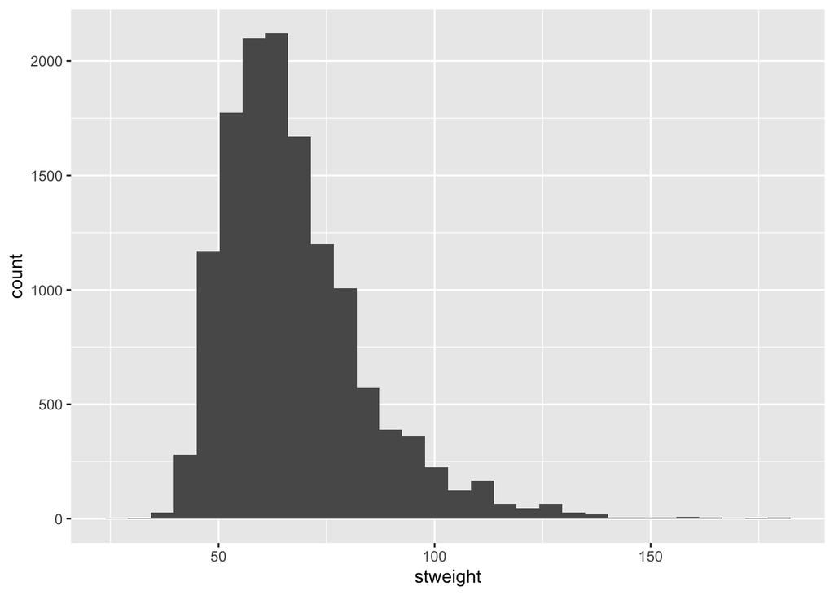

```r
ggplot(yrbss_data, aes(x = stweight)) +
  geom_histogram()
```

The student weights have a skewed right distribution, with a long tail for higher weights.

2. What happens if you change `x =` to `y =` in the histogram code?

The axes are flipped and we get a horizontal histogram.

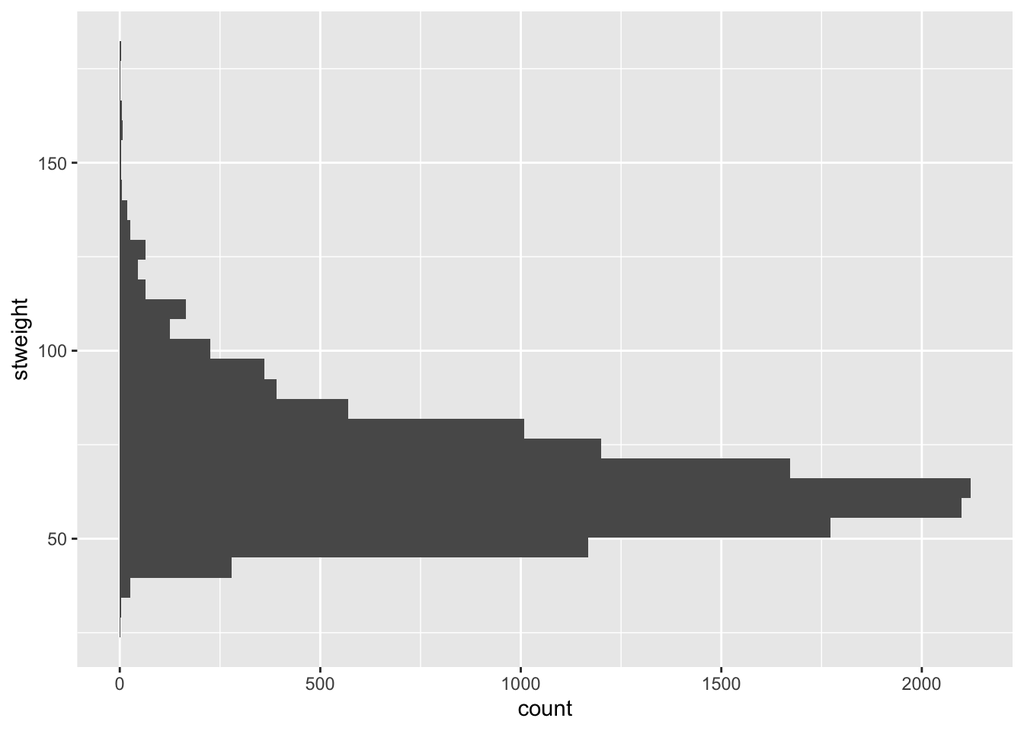

```r
ggplot(yrbss_data, aes(y = stweight)) +
  geom_histogram() # axes are flipped
```

3. Create boxplots of `stweight` stratified by sex.

The weights of males are slightly greater than for females.

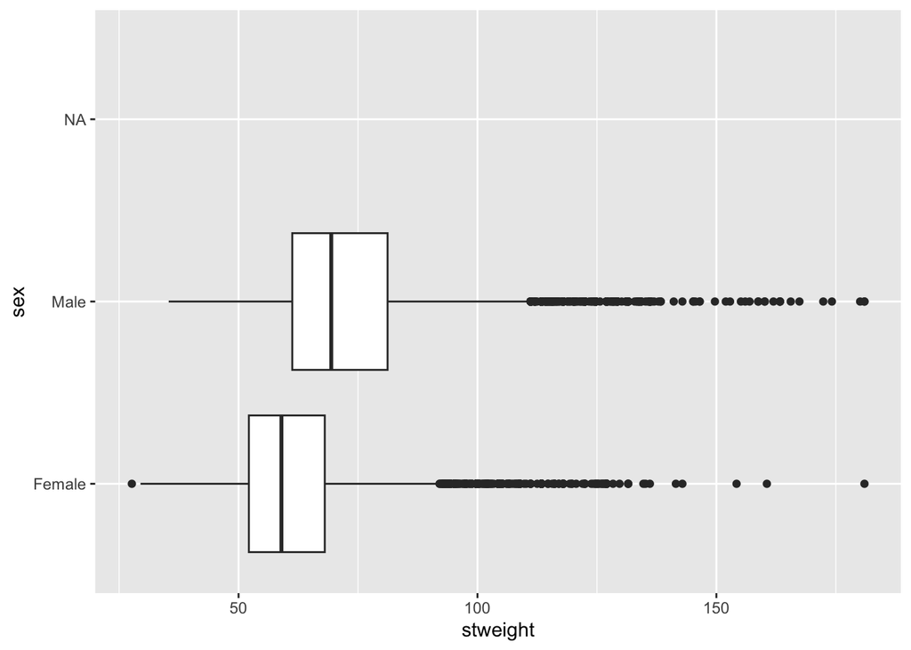

```r
ggplot(yrbss_data,
       aes(x = stweight, y = sex)) +
  geom_boxplot()
```

4. Create a barplot of race4 categories with the y axis showing percentages.

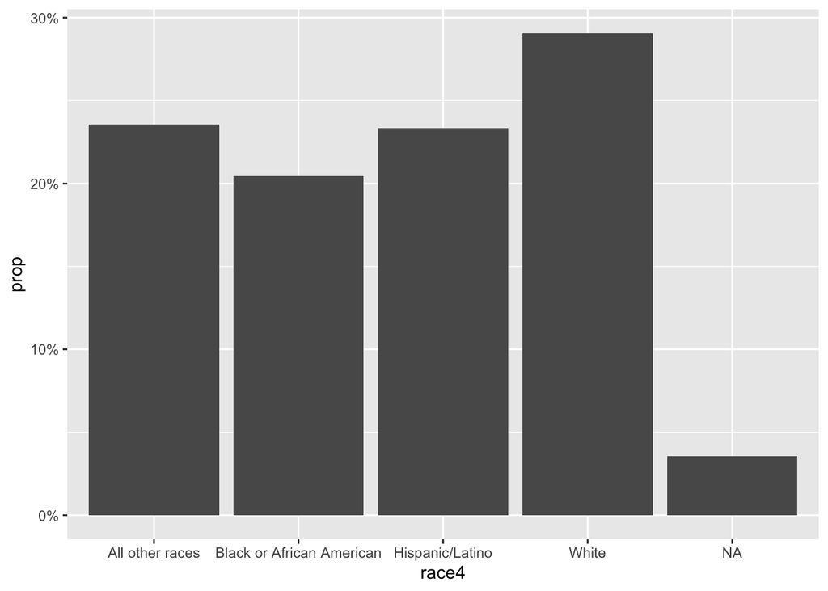

```r
ggplot(data = yrbss_data,
       aes(x = race4)) +
  # specify aesthetics within the barplot to show proportions
  geom_bar(aes(y = after_stat(prop), group = 1)) +
  # Next line converts y-axis labels to percentages instead of proportions
  scale_y_continuous(labels =  scales::percent_format())
```

5. Visualize the missing data across the YRBSS subset dataset we created `toy_data` using `vis_miss()`. What missingness patterns do you see?

We see a lot of missingness in the `text_while_driving` variable (about half missing), and some missingness for `smoked_ever`, `bullied_past_12mo`, and `race4`.

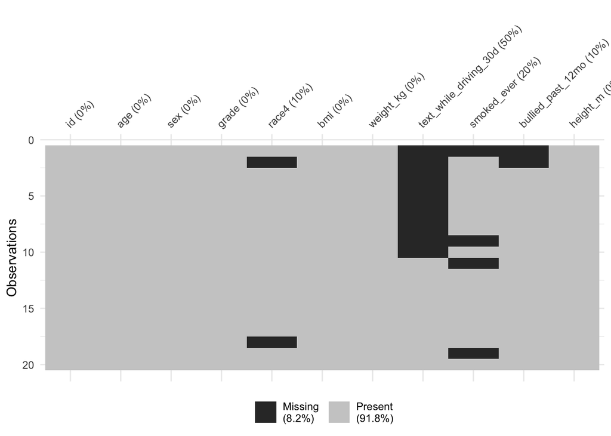

```r
toy_data <- read_excel("data/toy_data.xlsx", na = "NA")

vis_miss(toy_data)
```

# 4 Practice time! (part 4)

Perform some subsetting functions on the `yrbss_data` data:

1. Use `filter()` to select people who are in 9th or 10th grade and who have BMI less than 25. Save the resulting data as `yrbss_filtered` tibble.

```r
# first let's see what the categories look like
yrbss_data %>%
  tabyl(grade)
```

```
 grade    n percent valid_percent
  10th 4907 0.24535     0.2504338
  11th 4891 0.24455     0.2496172
  12th 4577 0.22885     0.2335919
   9th 5219 0.26095     0.2663570
  <NA>  406 0.02030            NA
```

```r
# now we filter with the "or" operator | on grade and then the "and" operator or comma on bmi
yrbss_filtered <- yrbss_data %>%
  filter(grade == "9th" | grade == "10th",
         bmi < 25
         )

# check this worked
nrow(yrbss_filtered)
```

```
[1] 5021
```

```r
yrbss_filtered %>%
  group_by(grade) %>%
  get_summary_stats(
    bmi,
    type = c("common")
    ) %>%
  gt()
```

| grade | variable | n | min | max | median | iqr | mean | sd | se | ci |
| --- | --- | --- | --- | --- | --- | --- | --- | --- | --- | --- |
| 10th | bmi | 2439 | 13.578 | 24.992 | 21.086 | 3.328 | 20.946 | 2.238 | 0.045 | 0.089 |
| 9th | bmi | 2582 | 13.161 | 24.995 | 20.535 | 3.234 | 20.600 | 2.273 | 0.045 | 0.088 |

```r
# Note that output only includes 9th & 10th grade
# and max BMI is < 25
```

2. Use `rename()` to rename 2 of the column names of `yrbss_filtered` to something more meaningful.

```r
names(yrbss_filtered)
```

```
[1] "record"   "age"      "sex"      "grade"    "race4"    "race7"    "bmi"
[8] "stweight"
```

```r
yrbss_filtered2 <- yrbss_filtered %>%
  rename(ID = record,
         weight = stweight)

names(yrbss_filtered2)
```

```
[1] "ID"     "age"    "sex"    "grade"  "race4"  "race7"  "bmi"    "weight"
```

3. Use `select()` to keep only the columns that denote record, sex, grade, bmi, and the 2 renamed columns.

```r
yrbss_filtered3 <- yrbss_filtered2 %>%
  select(ID, sex, grade, bmi, weight)

# check:
glimpse(yrbss_filtered3)
```

```
Rows: 5,021
Columns: 5
$ ID     <dbl> 931897, 1303997, 1096939, 1307180, 1312128, 1103656, 330828, 13…
$ sex    <chr> "Female", "Male", "Male", "Male", "Female", "Female", "Female",…
$ grade  <chr> "10th", "9th", "9th", "10th", "10th", "10th", "9th", "10th", "1…
$ bmi    <dbl> 17.1790, 24.4922, 17.0725, 21.7731, 21.9753, 20.8288, 20.3750, …
$ weight <dbl> 54.43, 66.68, 45.36, 66.68, 65.77, 55.34, 52.16, 97.52, 58.97, …
```

4. Arrange the data by bmi, starting with the highest value and ending with the least value.

```r
yrbss_filtered3 <- yrbss_filtered3 %>%
  arrange(desc(bmi))

yrbss_filtered3
```

```
# A tibble: 5,021 × 5
        ID sex    grade   bmi weight
     <dbl> <chr>  <chr> <dbl>  <dbl>
 1 1310909 Female 9th    25.0   49.0
 2 1104840 Female 9th    25.0   68.0
 3  932194 Female 9th    25.0   68.0
 4  923724 Male   10th   25.0   68.0
 5  636375 Female 9th    25.0   68.0
 6  636546 Female 9th    25.0   68.0
 7 1312932 Female 10th   25.0   68.0
 8 1104332 Female 10th   25.0   68.0
 9 1312269 Female 9th    25.0   68.0
10  630491 Male   10th   25.0   68.0
# ℹ 5,011 more rows
```

5. Save the resulting data set in the file `data/practice4_data.xslx`.

```r
write_xlsx(yrbss_filtered3, path = "data/practice4_data.xlsx")
```

# 5 Practice time! (part 5)

1. Create a new variable `height` that calculates height based on `bmi` and `weight_kg`. Note the formula for BMI is weight/height^2 (weight is in kilograms and height is in meters). Create a scatterplot of `bmi` vs `height`.

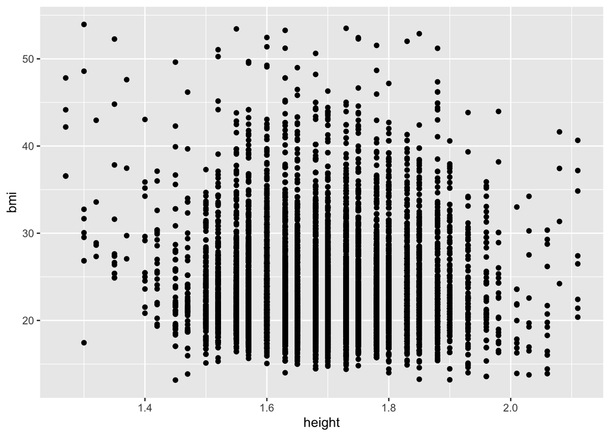

```r
yrbss_data <- yrbss_data %>%
  mutate(height = sqrt(stweight/bmi))

ggplot(yrbss_data, aes(x=height, y = bmi)) +
  geom_point()
```

2. Create a new factor variable `sex_fac` that orders the values of `sex` as Male, Female.

```r
yrbss_data <- yrbss_data %>%
  mutate(sex_fac = factor(sex,
                          levels = c("Male", "Female")))

# check:
glimpse(yrbss_data)
```

```
Rows: 20,000
Columns: 10
$ record   <dbl> 931897, 333862, 36253, 1095530, 1303997, 261619, 926649, 1309…
$ age      <chr> "15 years old", "17 years old", "18 years old or older", "15 …
$ sex      <chr> "Female", "Female", "Male", "Male", "Male", "Male", "Male", "…
$ grade    <chr> "10th", "12th", "11th", "10th", "9th", "9th", "11th", "12th",…
$ race4    <chr> "White", "White", "Hispanic/Latino", "Black or African Americ…
$ race7    <chr> "White", "White", "Hispanic/Latino", "Black or African Americ…
$ bmi      <dbl> 17.1790, 20.2487, NA, 27.9935, 24.4922, NA, 20.5435, 19.2555,…
$ stweight <dbl> 54.43, 57.15, NA, 85.73, 66.68, NA, 70.31, 58.97, 123.38, NA,…
$ height   <dbl> 1.780001, 1.680001, NA, 1.749999, 1.650000, NA, 1.849998, 1.7…
$ sex_fac  <fct> Female, Female, Male, Male, Male, Male, Male, Male, Male, Mal…
```

```r
yrbss_data %>% tabyl(sex_fac, sex)
```

```
 sex_fac Female  Male NA_
    Male      0 10177   0
  Female   9592     0   0
    <NA>      0     0 231
```

# 6 Practice time! (part 6)

1. Create a new category variable called `grade_num` in `yrbss_data` that converts `grade` to numeric.

```r
yrbss_data %>% tabyl(grade)
```

```
 grade    n percent valid_percent
  10th 4907 0.24535     0.2504338
  11th 4891 0.24455     0.2496172
  12th 4577 0.22885     0.2335919
   9th 5219 0.26095     0.2663570
  <NA>  406 0.02030            NA
```

```r
yrbss_data <- yrbss_data %>%
  mutate(grade_num =
           case_when(
             grade == "10th" ~ 10,
             grade == "11th" ~ 11,
             grade == "12th" ~ 12,
             grade == "9th" ~ 9))

# check:
yrbss_data %>% tabyl(grade, grade_num)
```

```
 grade    9   10   11   12 NA_
  10th    0 4907    0    0   0
  11th    0    0 4891    0   0
  12th    0    0    0 4577   0
   9th 5219    0    0    0   0
  <NA>    0    0    0    0 406
```

```r
glimpse(yrbss_data)
```

```
Rows: 20,000
Columns: 11
$ record    <dbl> 931897, 333862, 36253, 1095530, 1303997, 261619, 926649, 130…
$ age       <chr> "15 years old", "17 years old", "18 years old or older", "15…
$ sex       <chr> "Female", "Female", "Male", "Male", "Male", "Male", "Male", …
$ grade     <chr> "10th", "12th", "11th", "10th", "9th", "9th", "11th", "12th"…
$ race4     <chr> "White", "White", "Hispanic/Latino", "Black or African Ameri…
$ race7     <chr> "White", "White", "Hispanic/Latino", "Black or African Ameri…
$ bmi       <dbl> 17.1790, 20.2487, NA, 27.9935, 24.4922, NA, 20.5435, 19.2555…
$ stweight  <dbl> 54.43, 57.15, NA, 85.73, 66.68, NA, 70.31, 58.97, 123.38, NA…
$ height    <dbl> 1.780001, 1.680001, NA, 1.749999, 1.650000, NA, 1.849998, 1.…
$ sex_fac   <fct> Female, Female, Male, Male, Male, Male, Male, Male, Male, Ma…
$ grade_num <dbl> 10, 12, 11, 10, 9, 9, 11, 12, 12, 10, 9, 10, 10, 11, 9, 10, …
```

2. Create a new variable called `race_cat` that relabels `race4` to have shorter race category names: W (White), H/L (Hispanic/Latino), B/AA (Black or African American), Other (All other races). Make `race_cat` a factor variable with levels ordered by the size of the group in descending order.

```r
yrbss_data %>% tabyl(race4) %>% arrange(desc(n))
```

```
                     race4    n percent valid_percent
                     White 5814 0.29070     0.3013997
           All other races 4713 0.23565     0.2443235
           Hispanic/Latino 4670 0.23350     0.2420943
 Black or African American 4093 0.20465     0.2121825
                      <NA>  710 0.03550            NA
```

```r
yrbss_data <- yrbss_data %>%
  mutate(race_cat = case_when(
    race4 == "White" ~ "W",
    race4 == "Hispanic/Latino" ~ "H/L",
    race4 == "Black or African American" ~ "B/AA",
    race4 == "All other races" ~ "Other"
  )) %>%
  mutate(race_cat = factor(race_cat, levels = c("W", "Other", "H/L", "B/AA")))
```

3. Create a `tabyl` of the new variable `race_cat` and `race4` to check your work, including the ordering of the factors.

```r
# Check:
yrbss_data %>% tabyl(race4, race_cat)
```

```
                     race4    W Other  H/L B/AA NA_
           All other races    0  4713    0    0   0
 Black or African American    0     0    0 4093   0
           Hispanic/Latino    0     0 4670    0   0
                     White 5814     0    0    0   0
                      <NA>    0     0    0    0 710
```

# 7 Practice time! (part 7)

1. Create a barplot of `race4`, faceted by `sex`.

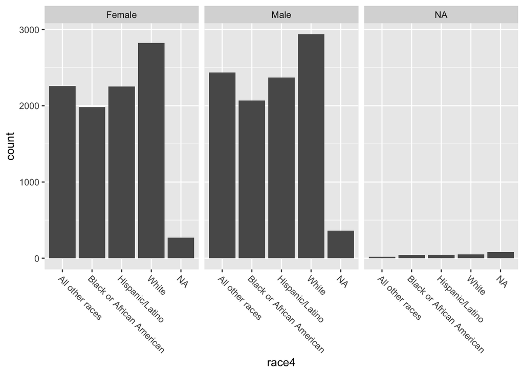

```r
ggplot(yrbss_data, aes(x=race4)) +
  geom_bar() +
  facet_wrap(vars(sex)) +
  theme(axis.text.x = element_text(angle = -45, hjust = 0))
```